# R Notebook docententraining

1. Start a new notebook via FILE - NEW FILE - R NOTEBOOK

For this Demo we will use the package Gapminder, this is the same as we saw in the introduction to the Tidyverse.

2. Install the package on your system. ….. How did we do this again? We will need the following packages: Gapminder, Tidyverse, dplyr, ggplot2

As we have installed the packages, R studio is familiar with the code and datasets the are included. However R studio does not know yet how to make use of these.

3. How can we enable these packages in R Studio, in such a way that we can access them from our notebook?

We want to start using Gapminder as our data set, though we first need to know what is in this table.

4. How can we ge the “complete” dataset of gapminder?

```
## # A tibble: 1,704 x 6
##    country     continent  year lifeExp      pop gdpPercap
##    <fct>       <fct>     <int>   <dbl>    <int>     <dbl>
##  1 Afghanistan Asia       1952    28.8  8425333      779.
##  2 Afghanistan Asia       1957    30.3  9240934      821.
##  3 Afghanistan Asia       1962    32.0 10267083      853.
##  4 Afghanistan Asia       1967    34.0 11537966      836.
##  5 Afghanistan Asia       1972    36.1 13079460      740.
##  6 Afghanistan Asia       1977    38.4 14880372      786.
##  7 Afghanistan Asia       1982    39.9 12881816      978.
##  8 Afghanistan Asia       1987    40.8 13867957      852.
##  9 Afghanistan Asia       1992    41.7 16317921      649.
## 10 Afghanistan Asia       1997    41.8 22227415      635.
## # ... with 1,694 more rows
```

5. How can we reduce the amount of lines we see in Gapminder to only the first 6 lines?

```
## # A tibble: 6 x 6
##   country     continent  year lifeExp      pop gdpPercap
##   <fct>       <fct>     <int>   <dbl>    <int>     <dbl>
## 1 Afghanistan Asia       1952    28.8  8425333      779.
## 2 Afghanistan Asia       1957    30.3  9240934      821.
## 3 Afghanistan Asia       1962    32.0 10267083      853.
## 4 Afghanistan Asia       1967    34.0 11537966      836.
## 5 Afghanistan Asia       1972    36.1 13079460      740.
## 6 Afghanistan Asia       1977    38.4 14880372      786.
```

6. What will happen with the code? Why would we do it like this?

```r
MijnDataset <- gapminder

MijnDataset
```

Given the following code:

7. what does the select command do? If you want to have more information about a set of code press F1, while having the code selected. (Hint, this is part of Rstudio, so you can always use this.)

```r
MijnDataset <- gapminder

select(MijnDataset, country, year)
```

8. What do you think will happen when executing this code?

You would get the same result if you use the following code:

9. Explain what happens.

```r
MijnDataset <- gapminder %>%

select(country, year)
```

10. We want to only see the countries with the population in 1957. You can use the filter option here, how would you proceed?

```
## # A tibble: 142 x 3
##    country      year      pop
##    <fct>       <int>    <int>
##  1 Afghanistan  1957  9240934
##  2 Albania      1957  1476505
##  3 Algeria      1957 10270856
##  4 Angola       1957  4561361
##  5 Argentina    1957 19610538
##  6 Australia    1957  9712569
##  7 Austria      1957  6965860
##  8 Bahrain      1957   138655
##  9 Bangladesh   1957 51365468
## 10 Belgium      1957  8989111
## # ... with 132 more rows
```

11. what is wrong with this part of the code? Why does this not show my information?

```r
MijnDataset <- gapminder

select(country, year, pop) %>%

  filter(year == 1957)
```

GGplot is used to make graphs. We will use this function on the gapminder set.

12. type ggplot, select the word, and press F1

You now see the information on ggplot. We want to have a barchart for the population per continent in 1957

13. first make sure that the subset of gapminder has the pop (population), continent and year (1957). (Hint, make use of select and filter)

```
## # A tibble: 142 x 3
##     year continent      pop
##    <int> <fct>        <int>
##  1  1957 Asia       9240934
##  2  1957 Europe     1476505
##  3  1957 Africa    10270856
##  4  1957 Africa     4561361
##  5  1957 Americas  19610538
##  6  1957 Oceania    9712569
##  7  1957 Europe     6965860
##  8  1957 Asia        138655
##  9  1957 Asia      51365468
## 10  1957 Europe     8989111
## # ... with 132 more rows
```

14. how do i check if this worked?

We have made the dataset object named MijnDataset. Now we want to make a barchart, what code would you use?

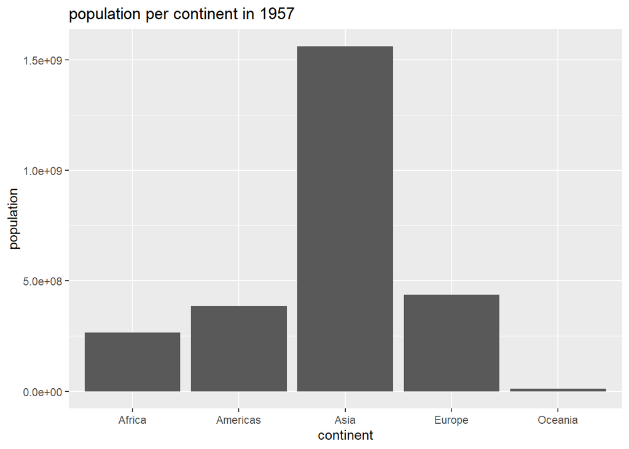

15. a student tried this chunk, though no result is given, what went wrong?

```r
MijnDataset <- gapminder %>%
  select(year, continent, pop) %>%
  filter(year == 1957)


ggplot(MijnDataset, aes(x = continent, y = pop)) +
  geom_bar()
```

16. a student tries to be quick and make the code more efficient with useing the pip command %>%. He gets an error, what went wrong?

```r
MijnDataset <- gapminder %>%
  select(year, continent, pop) %>%
  filter(year == 1957) %>%


ggplot(MijnDataset, aes(x = continent, y = pop)) +
  geom_bar(stat = "identity")
```

17. using this code, the program compiles, yet there is no graph, why not?

```r
MijnDataset <- gapminder %>%
  select(year, continent, pop) %>%
  filter(year == 1957) %>%


ggplot(aes(x = continent, y = pop)) +
  geom_bar(stat = "identity")
```

18. We want our graphs to look smooth. making use of a title, a description on the x and y axis. What could we do to make this graph? (remember the F1)